# Exercise_set_2

```python
%matplotlib inline
import numpy as np
import pandas as pd
import matplotlib.pyplot as plt
import matplotlib as mpl
import seaborn as sns

from scipy import stats
from sklearn.linear_model import LinearRegression
```

### 1. Load and clean data

So we need to read the data, name columns and take mean over Videos for each Subject

```python
data=pd.read_csv("./data/EEG data.csv", header=None)

names={0: "Subject ID", 1: "Video ID",2:"Attention",3:"Mediation",4:"Raw",5: "Delta",6:" Theta",7: "Alpha 1",8: "Alpha 2",9: "Beta 1", 10: "Beta 2" ,11: "Gamma 1", 12: "Gamma 2",13: "predefined label", 14: "user-defined label"}
data=data.rename(columns=names)

data=data.groupby(["Subject ID", "Video ID"]).mean()
```

### 2. Outlier Analysis

Let us look at the attention and Mediation columns.

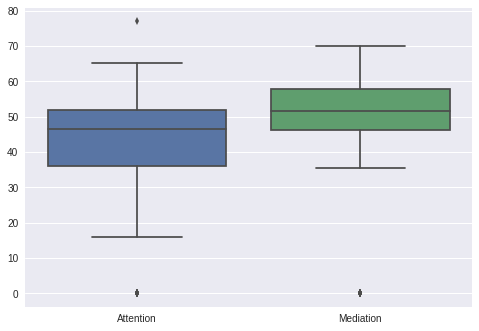

```python
sns.boxplot(data[["Attention","Mediation"]])
```

So there are several outliers. First that we can see, that there are some 0 values. Let's find them.

```python
data[(data["Attention"]==0)|(data["Mediation"]==0)]
```

| Subject ID | Video ID | Attention | Mediation | Raw | Delta | Theta | Alpha 1 | Alpha 2 | Beta 1 | Beta 2 | Gamma 1 | Gamma 2 | predefined label | user-defined label |
| --- | --- | --- | --- | --- | --- | --- | --- | --- | --- | --- | --- | --- | --- | --- |
| 3.0 | 3.0 | 0.0 | 0.0 | 44.159722 | 679609.430556 | 132381.784722 | 42858.180556 | 23484.263889 | 14489.062500 | 51326.986111 | 13870.298611 | 1893.527778 | 0.0 | 0.0 |
| 6.0 | 0.0 | 0.0 | 0.0 | 367.642857 | 807545.850000 | 401609.450000 | 112919.500000 | 141040.735714 | 81007.964286 | 112267.421429 | 73135.285714 | 79095.264286 | 0.0 | 1.0 |
|  | 1.0 | 0.0 | 0.0 | 245.119718 | 595207.845070 | 231366.323944 | 41717.626761 | 46124.112676 | 48270.035211 | 275703.880282 | 287988.795775 | 76448.253521 | 0.0 | 0.0 |
|  | 2.0 | 0.0 | 0.0 | 263.959016 | 584569.704918 | 225168.729508 | 38174.024590 | 39712.155738 | 47837.540984 | 276137.368852 | 241545.213115 | 82950.344262 | 0.0 | 0.0 |
|  | 3.0 | 0.0 | 0.0 | 355.336207 | 855490.258621 | 342884.922414 | 125175.672414 | 131039.500000 | 96779.896552 | 130072.508621 | 92971.060345 | 88753.534483 | 0.0 | 1.0 |
|  | 4.0 | 0.0 | 0.0 | 199.187500 | 733256.729167 | 255086.090278 | 55608.263889 | 51380.472222 | 56770.826389 | 297833.263889 | 283081.881944 | 97845.972222 | 0.0 | 1.0 |
|  | 5.0 | 0.0 | 0.0 | 395.211382 | 675630.024390 | 171916.975610 | 44623.520325 | 67194.674797 | 49157.894309 | 104084.016260 | 109254.373984 | 52460.349593 | 1.0 | 0.0 |
|  | 6.0 | 0.0 | 0.0 | 418.474138 | 793951.129310 | 247062.775862 | 42978.517241 | 75027.982759 | 61951.905172 | 159168.862069 | 146848.155172 | 66681.189655 | 1.0 | 1.0 |
|  | 7.0 | 0.0 | 0.0 | 575.557522 | 755965.451327 | 172671.761062 | 56392.849558 | 66123.716814 | 55284.522124 | 59506.106195 | 53265.513274 | 49019.353982 | 1.0 | 0.0 |
|  | 8.0 | 0.0 | 0.0 | 426.967213 | 879076.180328 | 241419.540984 | 83642.090164 | 93757.442623 | 64246.565574 | 83454.622951 | 55968.057377 | 56787.360656 | 1.0 | 1.0 |
|  | 9.0 | 0.0 | 0.0 | 300.868613 | 822708.664234 | 208945.313869 | 67313.576642 | 77372.233577 | 51915.080292 | 72598.350365 | 61240.481752 | 49866.518248 | 1.0 | 0.0 |

These outliers 0 values are common. As we can see, there is a problem with subject 6, so let's delete this subject. During 3 video of the 3rd subject also something happened with the recording of Attention and Mediation, so this recording also bad for our regression analysis. I will just delete all the rows above.

```python
data=data[~((data["Attention"]==0)|(data["Mediation"]==0))]
data[(data["Attention"]==0)|(data["Mediation"]==0)]
```

|  |  | Attention | Mediation | Raw | Delta | Theta | Alpha 1 | Alpha 2 | Beta 1 | Beta 2 | Gamma 1 | Gamma 2 | predefined label | user-defined label |
| --- | --- | --- | --- | --- | --- | --- | --- | --- | --- | --- | --- | --- | --- | --- |
| Subject ID | Video ID |  |  |  |  |  |  |  |  |  |  |  |  |  |

After we delete some recordings that are obviously spoiled.,we can look once more at our data.

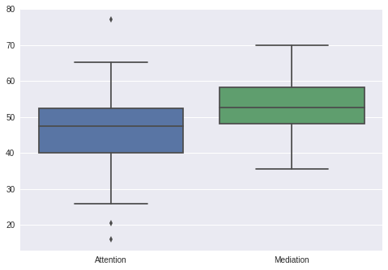

```python
sns.boxplot(data[["Attention","Mediation"]])
```

Let's delete all the values outside $\pm 3\sigma$

```python
data[(data["Mediation"]>data["Mediation"].quantile(0.9985))|
     (data["Mediation"]<data["Mediation"].quantile(0.0015))|
     (data["Attention"]>data["Attention"].quantile(0.9985))|
     (data["Attention"]<data["Attention"].quantile(0.0015))]
```

| Subject ID | Video ID | Attention | Mediation | Raw | Delta | Theta | Alpha 1 | Alpha 2 | Beta 1 | Beta 2 | Gamma 1 | Gamma 2 | predefined label | user-defined label |
| --- | --- | --- | --- | --- | --- | --- | --- | --- | --- | --- | --- | --- | --- | --- |
| 1.0 | 3.0 | 15.905172 | 35.560345 | 35.810345 | 844329.551724 | 281278.853448 | 67715.224138 | 39676.775862 | 28128.543103 | 26739.603448 | 13088.482759 | 3338.301724 | 0.0 | 1.0 |
| 2.0 | 5.0 | 77.024390 | 64.886179 | 43.991870 | 96940.105691 | 38518.951220 | 13135.284553 | 11523.105691 | 15234.991870 | 12903.845528 | 8437.260163 | 6483.878049 | 1.0 | 1.0 |
| 4.0 | 5.0 | 58.463415 | 69.975610 | 23.113821 | 247162.113821 | 88324.512195 | 20752.512195 | 18107.382114 | 14827.056911 | 15787.186992 | 9590.813008 | 7072.113821 | 1.0 | 0.0 |

```python
data=data[~((data["Mediation"]>data["Mediation"].quantile(0.9985))|
       (data["Mediation"]<data["Mediation"].quantile(0.0015))|
       (data["Attention"]>data["Attention"].quantile(0.9985))|
       (data["Attention"]<data["Attention"].quantile(0.0015)))]
```

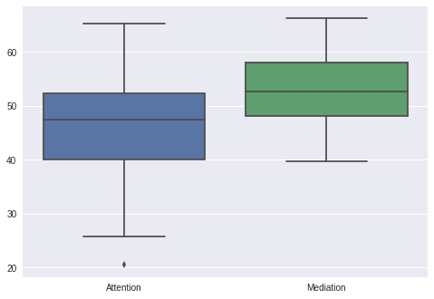

```python
sns.boxplot(data[["Attention","Mediation"]])
```

### 3. Predictor distributions and correlations

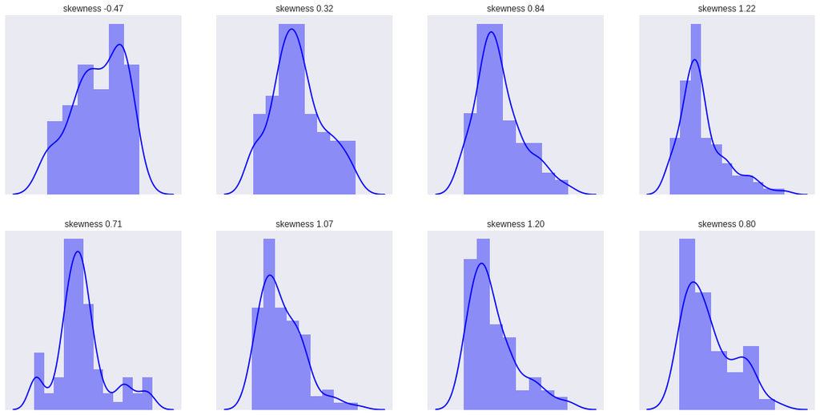

```python
features =["Delta"," Theta", "Alpha 1", "Alpha 2", "Beta 1", "Beta 2" , "Gamma 1", "Gamma 2"]
X=data[features]
skew=X.skew(axis=0)
# Set up the matplotlib figure
f, axes = plt.subplots(2,4, figsize=(20, 10), sharex=False)
sns.despine(left=True)
for ax,feature in zip(axes.flatten(),features):
    sns.distplot(data[feature].values, color="b", ax=ax)
    ax.set_title("skewness {0:.2f}".format(skew[feature]))
plt.setp(axes, yticks=[]);
plt.setp(axes, xticks=[]);
```

Let's apply Box-Cox correction to the features where skewness is larger than $\frac{2}{3}$.

```python
print(skew)
for feature in list(skew[np.abs(skew)>2/3].index):
    X.loc[:,feature]=stats.boxcox(X.loc[:,feature].values)[0]
```

```
Delta     -0.471270
 Theta     0.317573
Alpha 1    0.836894
Alpha 2    1.218873
Beta 1     0.713732
Beta 2     1.067625
Gamma 1    1.202675
Gamma 2    0.802285
dtype: float64
```

Let's check that we correct all skewed features

```python
X.skew(axis=0)
```

```
Delta     -0.471270
 Theta     0.317573
Alpha 1   -0.022571
Alpha 2    0.002847
Beta 1     0.041769
Beta 2    -0.019734
Gamma 1   -0.023488
Gamma 2   -0.016401
dtype: float64
```

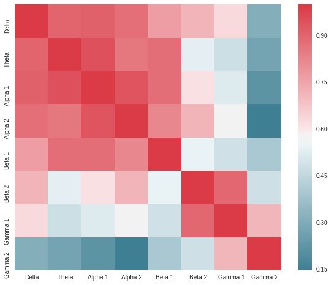

```python
f, ax = plt.subplots(figsize=(10, 8))
corr = X.corr()
sns.heatmap(corr, mask=np.zeros_like(corr, dtype=np.bool), cmap=sns.diverging_palette(220, 10, as_cmap=True),
            square=True, ax=ax)
```

We can see that slow frequency features correlate with each other.

It is also useful to plot correlation between every pair of features.

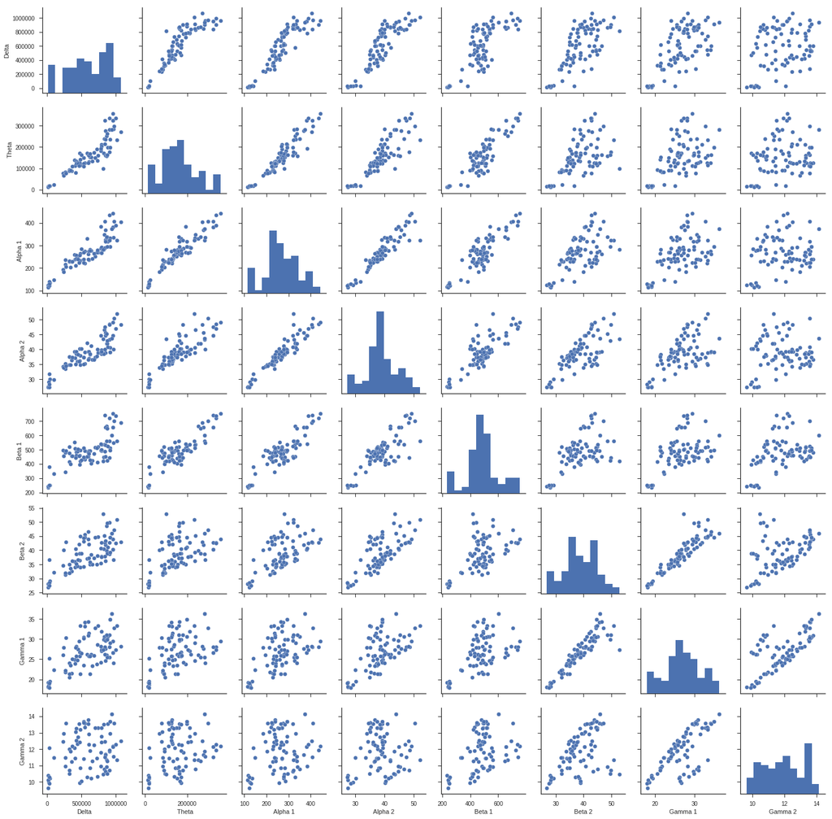

```python
plt.figure(figsize=(20,20))
sns.set(style="ticks", color_codes=True)
sns.pairplot(X)
```

### 3. Basic linear regression

I decided to add linear regression line with 95% confidence interval.

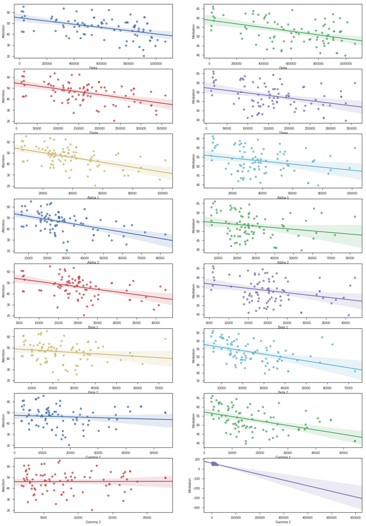

```python
features = ["Delta"," Theta", "Alpha 1", "Alpha 2", "Beta 1", "Beta 2" , "Gamma 1", "Gamma 2"]
targets = ["Attention", "Mediation"]
f, axes = plt.subplots(8, 2, figsize=(20, 30), sharex=False)
for i,feature in enumerate(features):
    for j,target in enumerate(targets):
            sns.regplot(x=feature, y=target, data=data,ax=axes[i,j])
```

```python
linear_model=LinearRegression(normalize=True)

# I get numply arrays of from DataFrames
X=data[features].values
y_att=data["Attention"].values
y_med=data["Mediation"].values
```

```python
y=y_att
linear_model.fit(X,y)
y_hat=linear_model.predict(X)
RMSE=(((y-y_hat)**2).mean())**(1/2)
print("RMSE for attention {0:.2f}".format(RMSE))
```

```
RMSE for attention 7.55
```

```python
y=y_med
linear_model.fit(X,y)
y_hat=linear_model.predict(X)
RMSE=(((y-y_hat)**2).mean())**(1/2)
print("RMSE for mediation {0:.2f}".format(RMSE))
```

```
RMSE for mediation 4.92
```

Let's add some interactions $x_6 \cdot x_0$, $x_6 \cdot x_2$ ,$x_6 \cdot x_4$ and $x_i^2$

```python
X=data[features].values
X=np.c_[X,X**2, X[:,6]*X[:,0],X[:,6]*X[:,2],X[:,6]*X[:,4]]
y=y_att
linear_model.fit(X,y)
y_hat=linear_model.predict(X)
data["Attention fitted"]=y_hat
data["Attention residuals"]=y-y_hat
RMSE=(((y-y_hat)**2).mean())**(1/2)
print("RMSE for attention {0:.2f}".format(RMSE))
y=y_med
linear_model.fit(X,y)
y_hat=linear_model.predict(X)
data["Mediation fitted"]=y_hat
data["Mediation residuals"]= y-y_hat
RMSE=(((y-y_hat)**2).mean())**(1/2)
print("RMSE for mediation {0:.2f}".format(RMSE))
```

```
RMSE for attention 6.83
RMSE for mediation 4.44
```

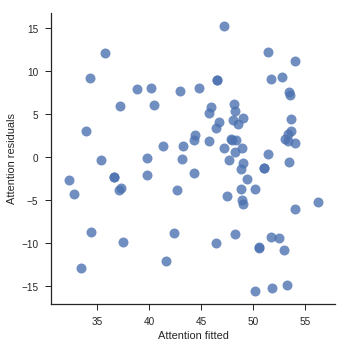

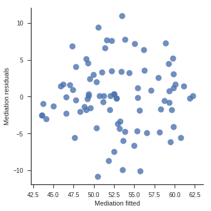

```python
sns.lmplot("Attention fitted", "Attention residuals",data=data,fit_reg=False,scatter_kws={"marker": "D","s": 100})

sns.lmplot("Mediation fitted", "Mediation residuals",data=data,fit_reg=False,scatter_kws={"marker": "D","s": 100})
```

Looks gut! Lets check normality

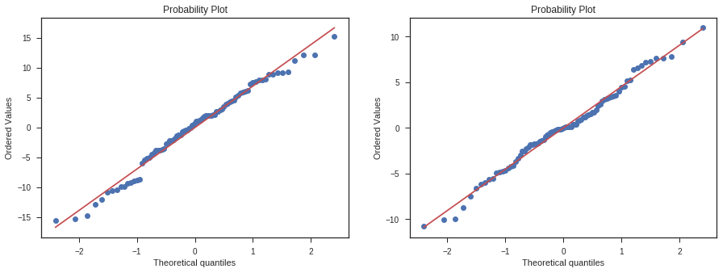

```python
import pylab
fig=plt.figure(figsize=(15,5))
fig.add_subplot(121)
stats.probplot(data["Attention residuals"], dist="norm", plot=pylab)
fig.add_subplot(122)
stats.probplot(data["Mediation residuals"], dist="norm", plot=pylab)
pylab.show()
```

### 5. Linear regression for prediction

```python
from sklearn.model_selection import cross_val_score, GridSearchCV
from sklearn.metrics import mean_squared_error
```

```python
X=data[features].values
X=np.c_[X,X**2, X[:,6]*X[:,0],X[:,6]*X[:,2],X[:,6]*X[:,4]]
y=y_att
scores = cross_val_score(linear_model, X, y, cv=5,scoring='neg_mean_squared_error')
RMSE=np.sqrt(-scores).mean()
print("RMSE for attention {0:.2f}".format(RMSE))
y=y_med
scores = cross_val_score(linear_model, X, y, cv=5,scoring='neg_mean_squared_error')
RMSE=np.sqrt(-scores).mean()
print("RMSE for mediation {0:.2f}".format(RMSE))
```

```
RMSE for attention 15.12
RMSE for mediation 9.53
```

The RMSE is higher than it was when we looked at the whole dataset. It indicated that before we overfit to our data. So maybe we need to add regularisation

#### Feature Selection

```python
from sklearn.feature_selection import SelectKBest
from sklearn.feature_selection import f_regression
from sklearn.feature_selection import chi2

X=data[features].values
X=np.c_[X,X**2, X[:,6]*X[:,0],X[:,6]*X[:,2],X[:,6]*X[:,4]]
y=y_med
X.shape
sel= SelectKBest(f_regression ,k=5)
X_new =sel.fit_transform(X,y)
```

```python
y=y_att
scores = cross_val_score(linear_model, X_new, y, cv=5,scoring='neg_mean_squared_error')
RMSE=np.sqrt(-scores).mean()
print("RMSE for attention {0:.2f}".format(RMSE))
y=y_med
scores = cross_val_score(linear_model, X_new, y, cv=5,scoring='neg_mean_squared_error')
RMSE=np.sqrt(-scores).mean()
print("RMSE for mediation {0:.2f}".format(RMSE))
```

```
RMSE for attention 9.07
RMSE for mediation 5.83
```